# jekyll-jupyter-notebook20240415-1921-bubrrn

### 5.4 Melakukan integrasi untuk mendapatkan simpangan (*displacement*) tanah

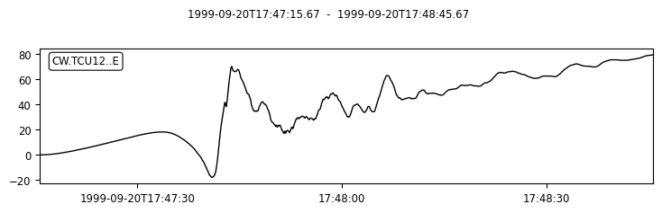

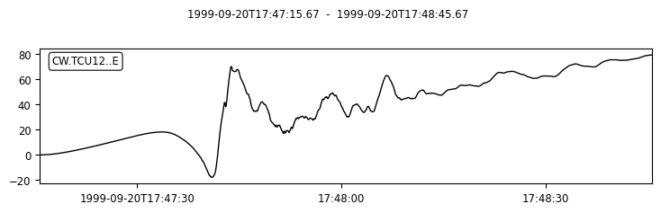

```python
sta_e_cor_fit_filt1_disp = sta_e_cor_fit_filt1_vel.copy()
sta_e_cor_fit_filt1_disp.integrate()

sta_e_cor_fit_filt1_disp.plot()
```

Efek dari sinyal transien masih terlihat dan mempengaruhi hasil konversi.

## 6 Mengaplikasikan Filter Kausal

Penyelesaian masalah sinyal transien pada filter (5) adalah dengan menggunakan filter kausal, proses yang dilakukan adalah mirip hanya saja untuk parameter `zerophase` diganti menjadi `False`:

### 6.1 Mengaplikasikan filter kausal

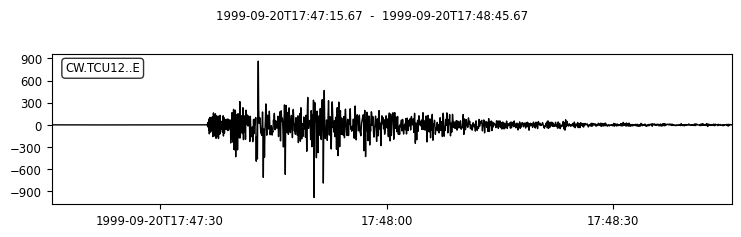

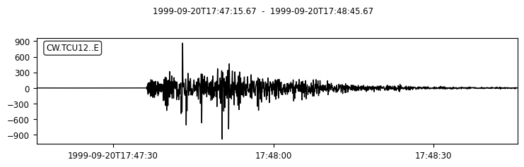

```python
f=0.05
zerophase=False
corner=2
sta_e_cor_fit_filt2 = sta_e_cor_fit.copy()
sta_e_cor_fit_filt2.filter('highpass', freq=f, zerophase=zerophase, corners=corner)
sta_e_cor_fit_filt2.plot()
```

### 6.2 Melakukan integrasi untuk mendapatkan kecepatahan getaran tanah

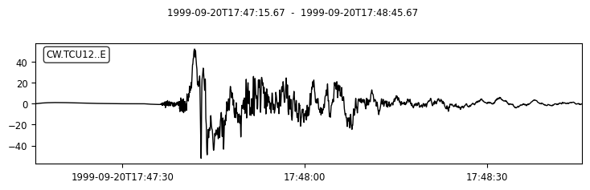

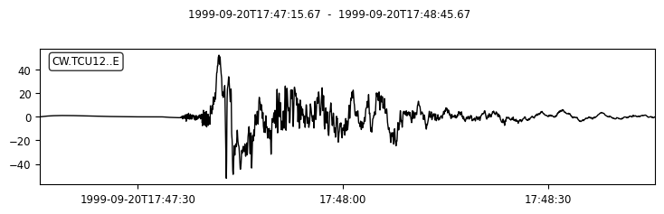

```python
sta_e_cor_fit_filt2_vel = sta_e_cor_fit_filt2.copy()
sta_e_cor_fit_filt2_vel.integrate()

sta_e_cor_fit_filt2_vel.plot()
```

Dari hasil *filter* di atas sinyal transien tidak muncul seperti pada kasus filter akausal.

### 6.3 Melakukan integrasi untuk mendapatkan simpangan tanah

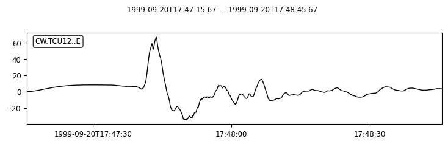

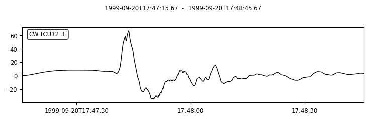

```python
sta_e_cor_fit_filt2_disp = sta_e_cor_fit_filt2_vel.copy()
sta_e_cor_fit_filt2_disp.integrate()

sta_e_cor_fit_filt2_disp.plot()
```

## 7 Menggunakan Metode Iwan dkk (1985) Opsi 1

Koreksi `baseline` yang sedikit lebih kompleks diperkenalkan oleh Iwan dkk (1985). Metode ini didasari dari adanya efek histerisis pada transduser ketika akselerasi melebihi 50 cm/s/s. Efek ini menimbulkan pergeseran akselerasi dalam bentuk *step* yang parameternya bisa didapatkan dari melakukan *fitting* garis lurus pada kecepatan.

### 7.1 Mendapatkan nili $t_1$ dan $t_2$ untuk analisis

Dengan metode Iwan opsi 1 analisis akan dibagi menjadi 3 bagian yang dibatasi oleh nilai $t_1$ dan nilai $t_2$. Data sebelum nilai $t_1$ merupakan data *pre-event*, diantara $t_1$ dan $t_2$ merupakan inti akselerasi tanah, dan setelah $t_1$ merupakan data setelah *event*. Nilai $t_1$ mengambil titik dimana nilai akselerasi pertama kali bernilai lebih dari 50 cm/s/s dan nilai $t_2$ adalah titik dimana data sudah mulai bernilai kurang dari 50 cm/s/s, berkaitan dengan fenomena histerisis tadi. Nilai $t_1$ dan $t_2$ dapat juga dikaitakan dengan periode guncangan yang tertinggi. Proses pengambilan nilai memanfaatkan `numpy.where` seperti proses sebelumnya:

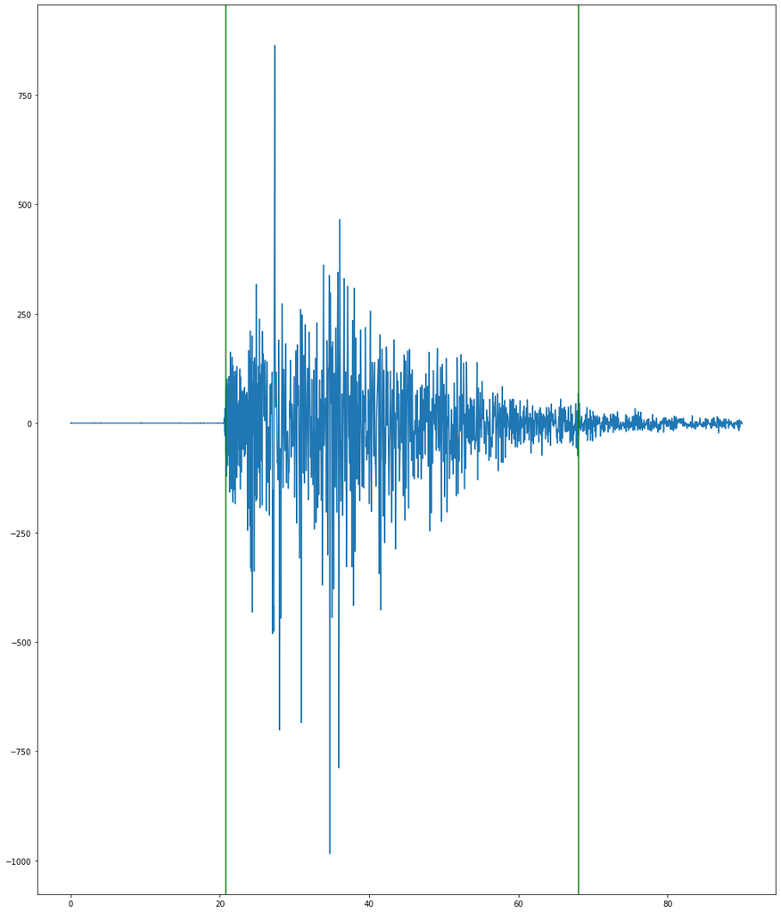

```python
import numpy as np
import matplotlib.pyplot as plt

sta_e_data = sta_e[0].data

sta_data_higher50_index = np.where((sta_e_data>50))

t1_index = sta_data_higher50_index[0][0]
t2_index = sta_data_higher50_index[0][-1] + 1

t1 = times[t1_index]
t2 = times[t2_index]

plt.plot(times, sta_e_data)
plt.axvline(x=t1, color="green")
plt.axvline(x=t2, color="green")
```

Dalam kecepatan:

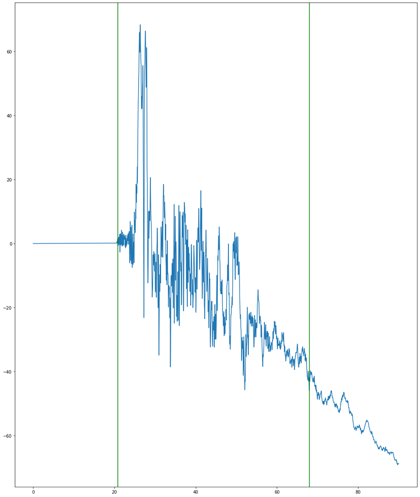

```python
stv_e_data = stv_e[0].data

plt.plot(times, stv_e_data)
plt.axvline(x=t1, color="green")
plt.axvline(x=t2, color="green")
```

### 7.2 Menghitung nilai $a_f$

$$ v_f(t) = v_0 + a_f t $$

Dalam penerapannya proses ini memanfaatkan *slicing* indeks dan perhitungan regresi menggunakan `scipy.stats.linregress`:

```
slope:  -1.156331846971815
```

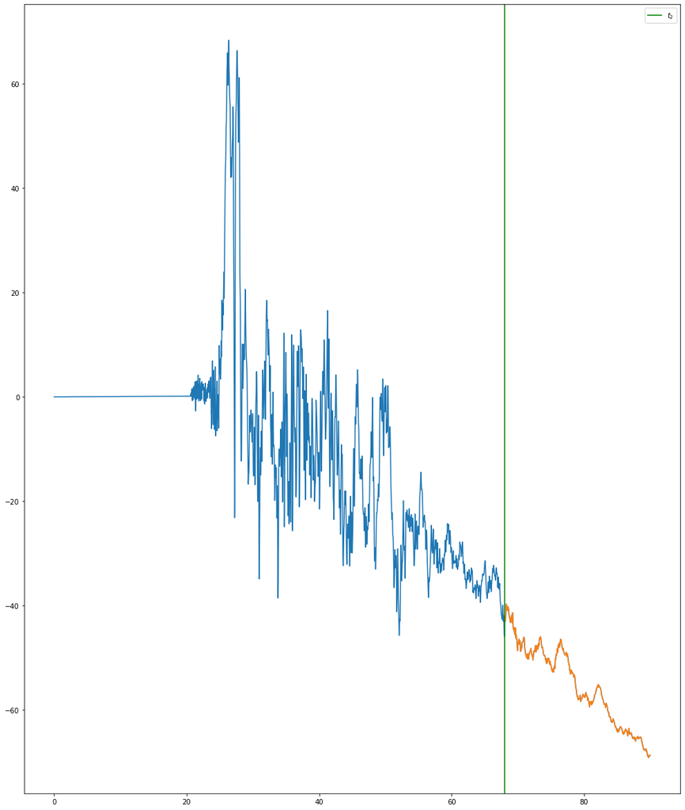

```python
import scipy

times_after_50 = times[t2_index:]
stv_e_data_after_50 = stv_e_data[t2_index:]

plt.plot(times, stv_e_data)
plt.plot(times_after_50, stv_e_data_after_50)

plt.axvline(x=t2, color="green", label="$t_2$")
regression_iwan1_after_50 = scipy.stats.linregress(times_after_50, stv_e_data_after_50)
print("slope: ",regression_iwan1_after_50[0])
plt.legend()
```

```
-1.156331846971815 36.24933248149239
```

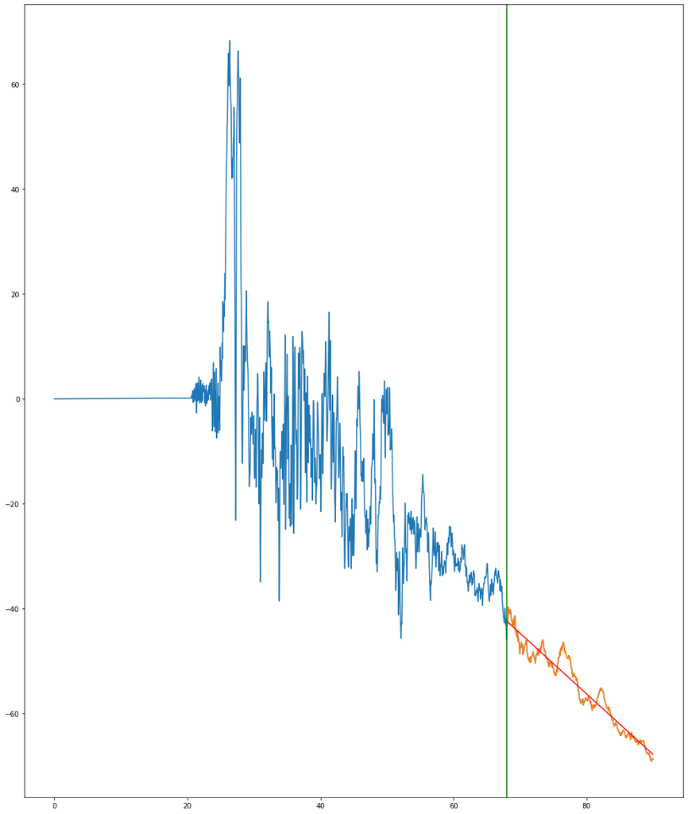

```python
regression_iwan1_after_50 = scipy.stats.linregress(times_after_50, stv_e_data_after_50)
slope_iwan1_after_50 = regression_iwan1_after_50[0]
intercept_iwan1_after_50 = regression_iwan1_after_50[1]

print(slope_iwan1_after_50, intercept_iwan1_after_50)
line_fit_iwan1_after_50 = times_after_50*slope_iwan1_after_50 + intercept_iwan1_after_50

plt.plot(times, stv_e_data)
plt.plot(times_after_50, stv_e_data_after_50)
plt.plot(times_after_50, line_fit_iwan1_after_50, color="red")
plt.axvline(x=t2, color="green")
```

Dari kode di atas didapatkan nilai $a_f=-1.156$

### 7.2 Menghitung nilai $a_m$

Nilai $a_m$ digunakan untuk koreksi data akselerasi di zona guncangan tinggi yaitu diantara $t_1$ dan $t_2$, nilai ini didapatkan dari melakukan regresi atau perhitungan gradien sederhana dari data antara $t_1$ dan $t_2$ dengan $v_f(t_1)=0$: $$ a_m = \frac{v_f(t_2)}{t_2-t_1} $$

Kita terlebih dahulu mengambil data antara $t_1$ dan $t_2$:

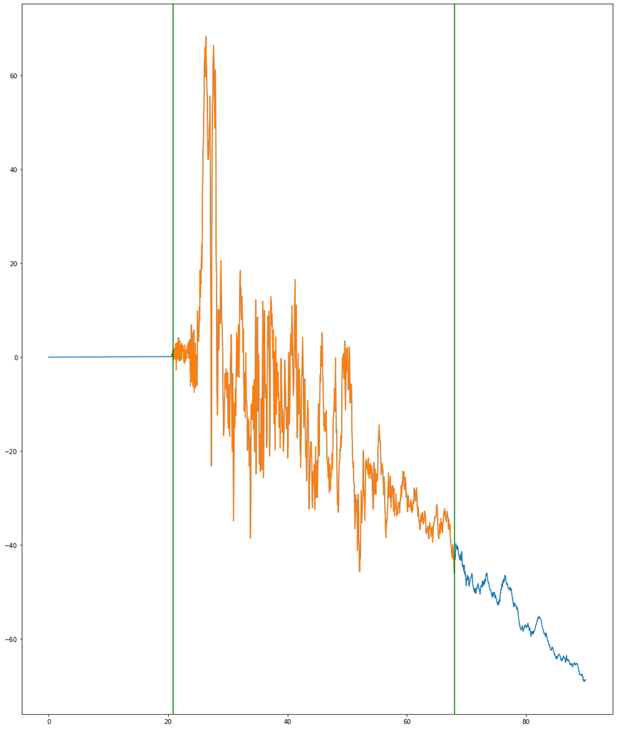

```python
times_between_50 = times[t1_index:t2_index]
stv_e_data_between_50 = stv_e_data[t1_index:t2_index]

plt.plot(times, stv_e_data)
plt.plot(times_between_50, stv_e_data_between_50)

plt.axvline(x=t1, color="green")
plt.axvline(x=t2, color="green")
```

kemudian melakukan regresi seperti pada proses sebelumnya:

```
-0.9154329987712069 19.646331011115382
slope:  -0.9154329987712069
```

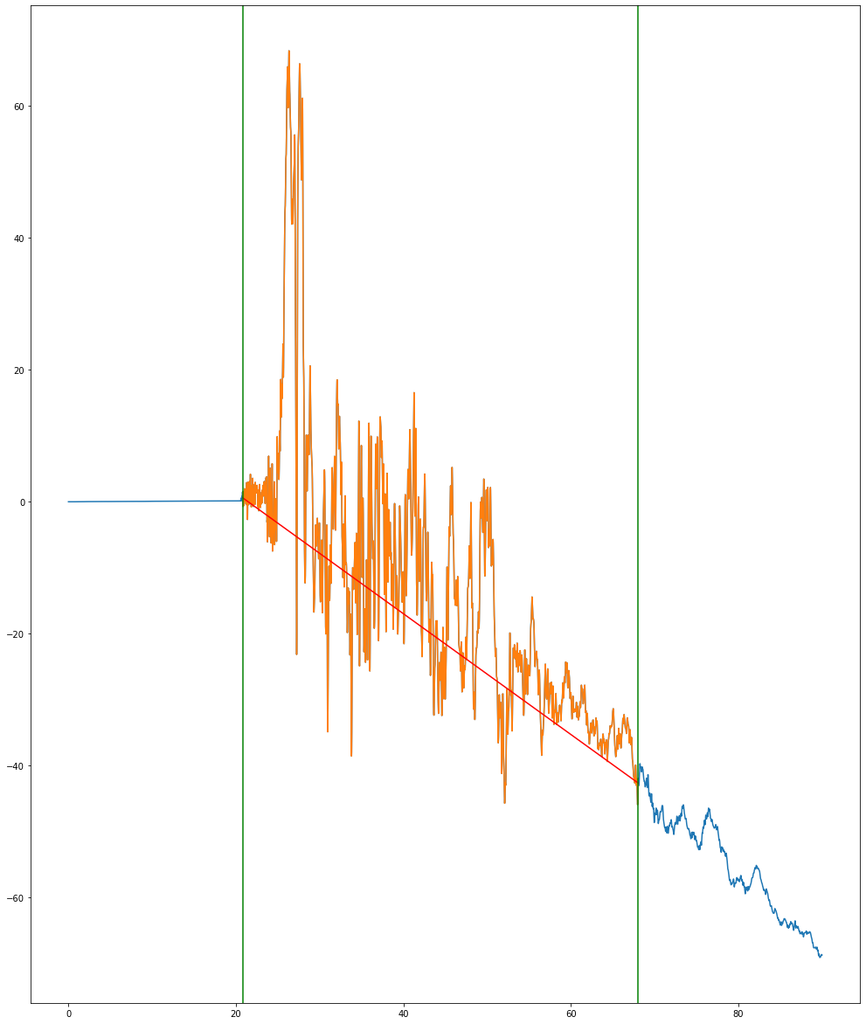

```python
import scipy

times_between_50_bound = [times_between_50[0],times_between_50[-1]]
stv_e_data_between_50_bound = [stv_e_data_between_50[0],stv_e_data_between_50[-1]]

regression_iwan1_between_50 = scipy.stats.linregress(times_between_50_bound, stv_e_data_between_50_bound)
slope_iwan1_between_50 = regression_iwan1_between_50[0]
intercept_iwan1_between_50 = regression_iwan1_between_50[1]

print(slope_iwan1_between_50, intercept_iwan1_between_50)
line_fit_iwan1_between_50 = times_between_50*slope_iwan1_between_50 + intercept_iwan1_between_50

plt.plot(times, stv_e_data)
plt.plot(times_between_50, stv_e_data_between_50)
plt.plot(times_between_50, line_fit_iwan1_between_50, color="red")
plt.axvline(x=t1, color="green")
plt.axvline(x=t2, color="green")
print("slope: ",slope_iwan1_between_50)
```

### 7.4 Membuat data koreksi dalam akselerasi

Dengan nilai $a_f$ dan $a_m$ maka kedua nilai tersebut dapat digunakan untuk mengoreksi data dalam akselerasi. Pertama kita harus membuat *placeholder* untuk meletakkan data koreksi, dibuat menggunakan vektor berisi 1 dengan panjang sesuai panjang data:

```python
sta_e_iwan1_cor_coeff = np.ones(len(sta_e_data))
sta_e_iwan1_cor_coeff
```

```
array([1., 1., 1., ..., 1., 1., 1.])
```

Selanjutnya masing-masing bagian diisi sesuai dengan nilainya:

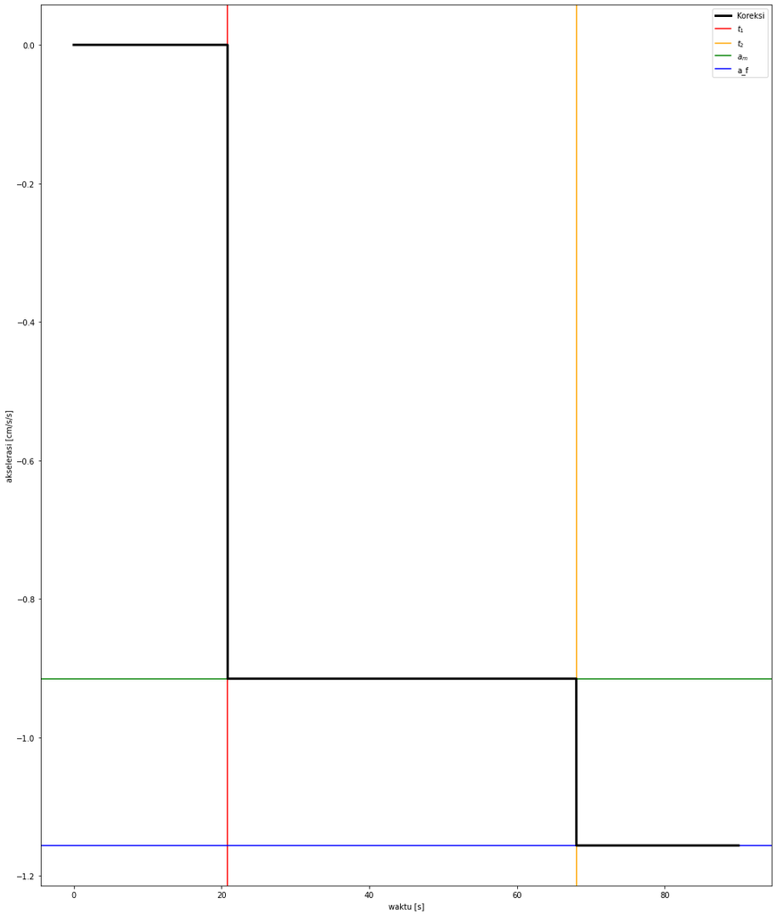

```python
sta_e_iwan1_cor_coeff[:t1_index] = 0
sta_e_iwan1_cor_coeff[t1_index:t2_index] = slope_iwan1_between_50
sta_e_iwan1_cor_coeff[t2_index:] = slope_iwan1_after_50

plt.plot(times, sta_e_iwan1_cor_coeff, zorder=110, linewidth=3, color="k", label="Koreksi")
plt.axvline(x=t1, label="$t_1$", color="red")
plt.axvline(x=t2, label="$t_2$", color="orange")
plt.axhline(y=slope_iwan1_between_50, color="green", label="$a_m$")
plt.axhline(y=slope_iwan1_after_50, color="blue", label="a_f")
plt.xlabel("waktu [s]")
plt.ylabel("akselerasi [cm/s/s]")
plt.legend()
```

### 7.5 Melakukan koreksi

Koreksi dilakukan dengan operasi matematika sederhana:

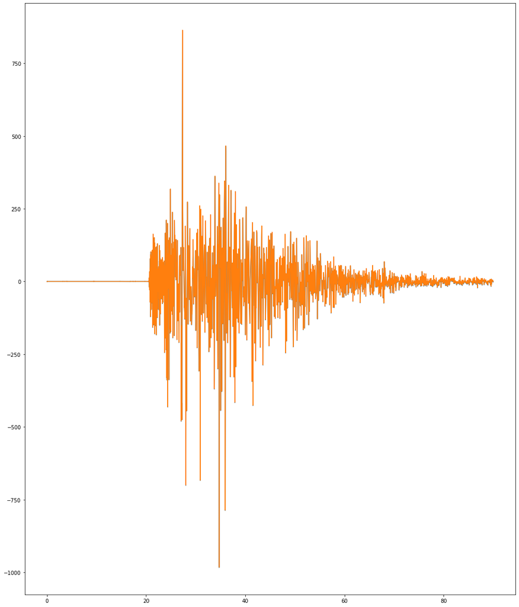

```python
sta_e_iwan1_corrected = sta_e_data - sta_e_iwan1_cor_coeff

plt.plot(times, sta_e_data)
plt.plot(times, sta_e_iwan1_corrected)
```

### 7.6 Mengintegrasikan untuk mendapatkan kecepatan

Data terkoreksi bisa dikonversi ke objek `Stream` untuk selanjutnya nanti dikonversi ke kecepatan:

```python
sta_e_cor_iwan1 = sta_e[0].copy()
sta_e_cor_iwan1.data = sta_e_iwan1_corrected
sta_e_cor_iwan1.plot()
```

[output not shown]

konversi ke kecepatan dengan integrasi:

```python
stv_e_cor_iwan1 = sta_e_cor_iwan1.copy()
stv_e_cor_iwan1.integrate()
stv_e_cor_iwan1.plot()
```

[output not shown]

### 7.7 Mengintegrasikan untuk mendapatkan simpangan tanah

Begitu pula untuk *displacement*

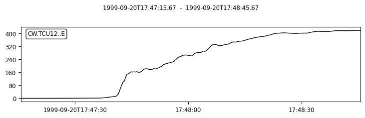

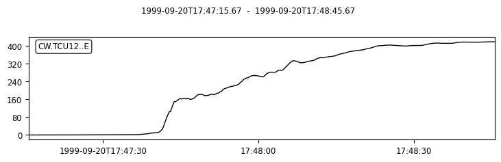

```python
std_e_cor_iwan1 = stv_e_cor_iwan1.copy()
std_e_cor_iwan1.integrate()
std_e_cor_iwan1.plot()
```

## 8 Membandingkan hasil koreksi

### 8.1 Perbandingan akselerasi

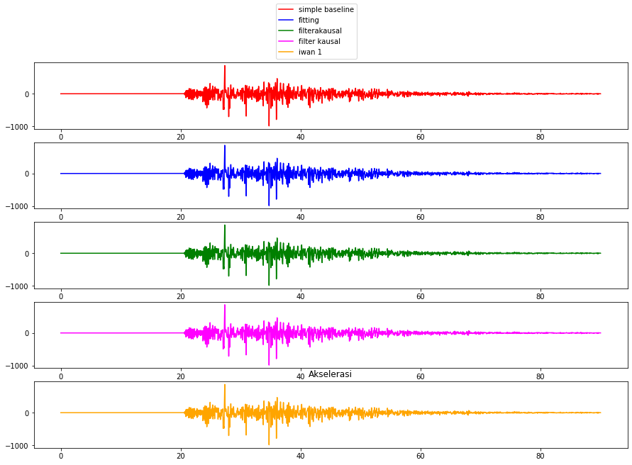

```python
import matplotlib.pyplot as plt

fig=plt.figure(figsize=(15,10))

# koreksi simple baseline
ax=fig.add_subplot(5,1,1)
ax.plot(times, sta_e_cor_simple.data, label='simple baseline', color="red")

# koreksi fitting
ax=fig.add_subplot(5,1,2)
ax.plot(times, sta_e_cor_fit.data, label='fitting', color="blue")

# filter akausal
ax=fig.add_subplot(5,1,3)
ax.plot(times, sta_e_cor_fit_filt1.data, label='filterakausal', color="green")

# filter kausal
ax=fig.add_subplot(5,1,4)
ax.plot(times, sta_e_cor_fit_filt2.data,label='filter kausal', color="magenta")

# metode iwan1
ax=fig.add_subplot(5,1,5)
ax.plot(times, sta_e_cor_iwan1.data, label='iwan 1', color="orange")

fig.legend(loc='upper center')
ax.set_title("Akselerasi")
```

### 8.2 Perbandingan kecepatan

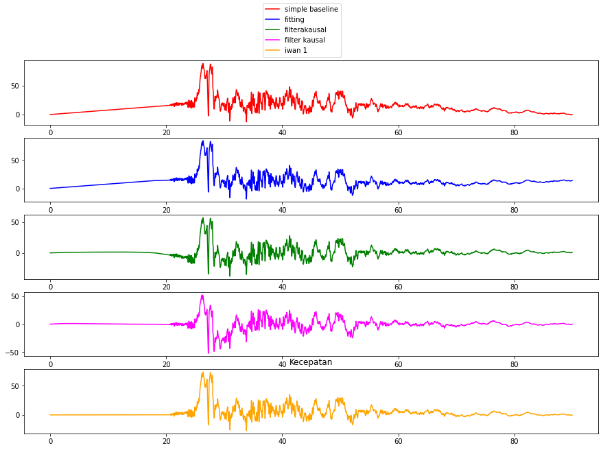

```python
import matplotlib.pyplot as plt

fig=plt.figure(figsize=(15,10))

# koreksi simple baseline
ax=fig.add_subplot(5,1,1)
ax.plot(times, sta_e_cor_simple_vel.data, label='simple baseline', color="red")

# koreksi fitting
ax=fig.add_subplot(5,1,2)
ax.plot(times, sta_e_cor_fit_vel.data, label='fitting', color="blue")

# filter akausal
ax=fig.add_subplot(5,1,3)
ax.plot(times, sta_e_cor_fit_filt1_vel.data, label='filterakausal', color="green")

# filter kausal
ax=fig.add_subplot(5,1,4)
ax.plot(times, sta_e_cor_fit_filt2_vel.data,label='filter kausal', color="magenta")

# metode iwan1
ax=fig.add_subplot(5,1,5)
ax.plot(times, stv_e_cor_iwan1.data, label='iwan 1', color="orange")

fig.legend(loc='upper center')
ax.set_title("Kecepatan")
```

### 8.3 Perbandingan *displacement*

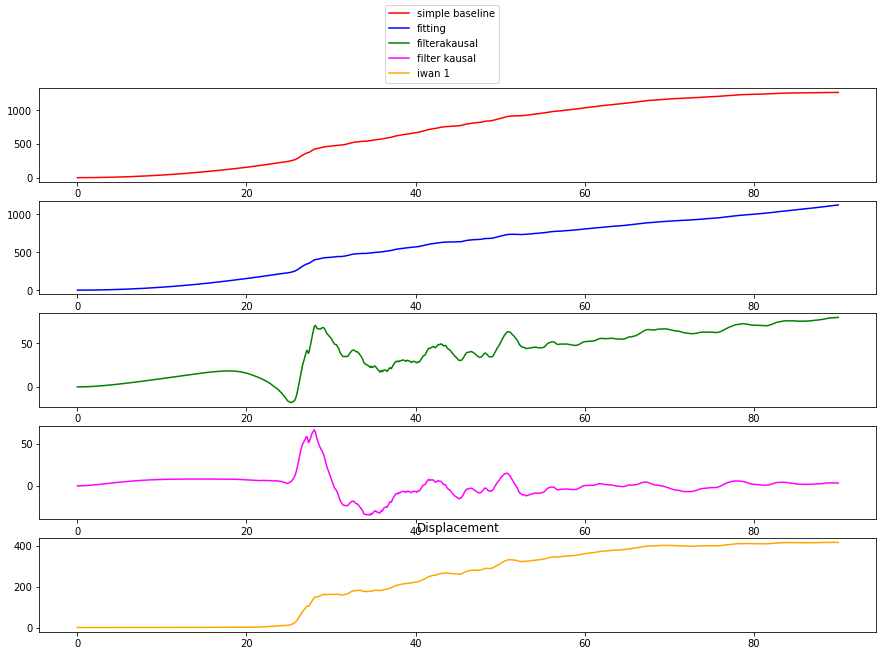

```python
import matplotlib.pyplot as plt

fig=plt.figure(figsize=(15,10))

# koreksi simple baseline
ax=fig.add_subplot(5,1,1)
ax.plot(times, sta_e_cor_simple_disp.data, label='simple baseline', color="red")

# koreksi fitting
ax=fig.add_subplot(5,1,2)
ax.plot(times, sta_e_cor_fit_disp.data, label='fitting', color="blue")

# filter akausal
ax=fig.add_subplot(5,1,3)
ax.plot(times, sta_e_cor_fit_filt1_disp.data, label='filterakausal', color="green")

# filter kausal
ax=fig.add_subplot(5,1,4)
ax.plot(times, sta_e_cor_fit_filt2_disp.data,label='filter kausal', color="magenta")

# metode iwan1
ax=fig.add_subplot(5,1,5)
ax.plot(times, std_e_cor_iwan1.data, label='iwan 1', color="orange")

fig.legend(loc='upper center')
ax.set_title("Displacement")
```

## 9 Latihan

### 9.1 Mendapatkan nilai $t_1$ dan $t_2$

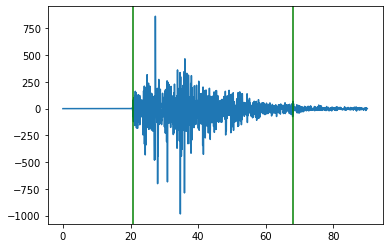

```python
import numpy as np
import matplotlib.pyplot as plt

sta_e_data = sta_e[0].data

sta_data_higher50_index = np.where(#isikan disini) <------------------------

t1_index = sta_data_higher50_index[0][0]
t2_index = sta_data_higher50_index[0][-1] + 1

t1 = times[t1_index]
t2 = times[t2_index]

plt.plot(times, sta_e_data)
plt.axvline(x=t1, color="green")
plt.axvline(x=t2, color="green")
```

### 9.2 Menghitung nilai $a_f$

```
slope:  -1.156331846971815
```

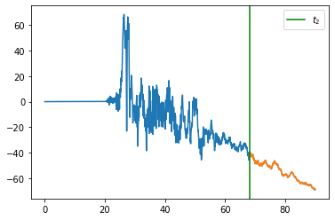

```python
import scipy

times_after_50 = times[#isi disini]
stv_e_data_after_50 = stv_e_data[#isi disini]

plt.plot(times, stv_e_data)
plt.plot(times_after_50, stv_e_data_after_50)

plt.axvline(x=t2, color="green", label="$t_2$")
regression_iwan1_after_50 = scipy.stats.linregress(#isi disini)
print("slope: ",regression_iwan1_after_50[0])
plt.legend()
```

### 9.3 Menghitung nilai $a_m$

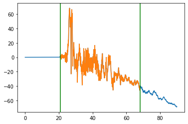

```python
times_between_50 = times[#isi disini]
stv_e_data_between_50 = stv_e_data[#isi disini]

plt.plot(times, stv_e_data)
plt.plot(times_between_50, stv_e_data_between_50)

plt.axvline(x=t1, color="green")
plt.axvline(x=t2, color="green")
```

### 9.4 Membuat data koreksi dalam akselerasi

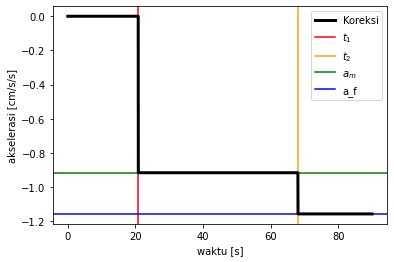

```python
sta_e_iwan1_cor_coeff = np.ones(#isi disini)

sta_e_iwan1_cor_coeff[#isi disini] = #isi disini
sta_e_iwan1_cor_coeff[#isi disini] = #isi disini
sta_e_iwan1_cor_coeff[#isi disini] = #isi disini

plt.plot(times, sta_e_iwan1_cor_coeff, zorder=110, linewidth=3, color="k", label="Koreksi")
plt.axvline(x=t1, label="$t_1$", color="red")
plt.axvline(x=t2, label="$t_2$", color="orange")
plt.axhline(y=slope_iwan1_between_50, color="green", label="$a_m$")
plt.axhline(y=slope_iwan1_after_50, color="blue", label="a_f")
plt.xlabel("waktu [s]")
plt.ylabel("akselerasi [cm/s/s]")
plt.legend()
```

### 9.5 Melakukan koreksi

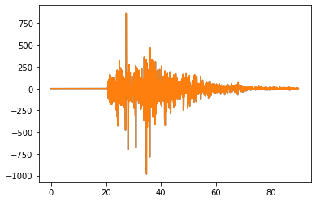

```python
sta_e_iwan1_corrected = #isi disini

plt.plot(times, sta_e_data)
plt.plot(times, sta_e_iwan1_corrected)
```

### 9.6 Mengintegrasikan untuk mendapatkan kecepatan

```python
sta_e_cor_iwan1 = sta_e[0].copy()
sta_e_cor_iwan1.data = #isi disini
sta_e_cor_iwan1.plot()

stv_e_cor_iwan1 = sta_e_cor_iwan1.copy()
#isi disini
stv_e_cor_iwan1.plot()
```

```python
%matplotlib inline
from obspy import *
from obspy.clients.fdsn import Client
import numpy as np
import matplotlib.pylab as plt
c = Client("IRIS")
tmp1 = UTCDateTime("1989-07-08T03:40:00.0")
tmp2 = UTCDateTime("1989-07-08T04:05:00.0")
dat = c.get_waveforms("CD", "WMQ", "", "BH*", tmp1, tmp2, attach_response = True)
dat.detrend('linear')
dat.detrend('demean')
dat.remove_response(output="VEL")
dat.detrend('linear')
dat.detrend('demean')
print(dat)
```

```
3 Trace(s) in Stream:
CD.WMQ..BHE | 1989-07-08T03:48:37.790000Z - 1989-07-08T04:04:41.040000Z | 20.0 Hz, 19266 samples
CD.WMQ..BHN | 1989-07-08T03:48:37.790000Z - 1989-07-08T04:04:41.040000Z | 20.0 Hz, 19266 samples
CD.WMQ..BHZ | 1989-07-08T03:48:37.790000Z - 1989-07-08T04:04:41.040000Z | 20.0 Hz, 19266 samples
```

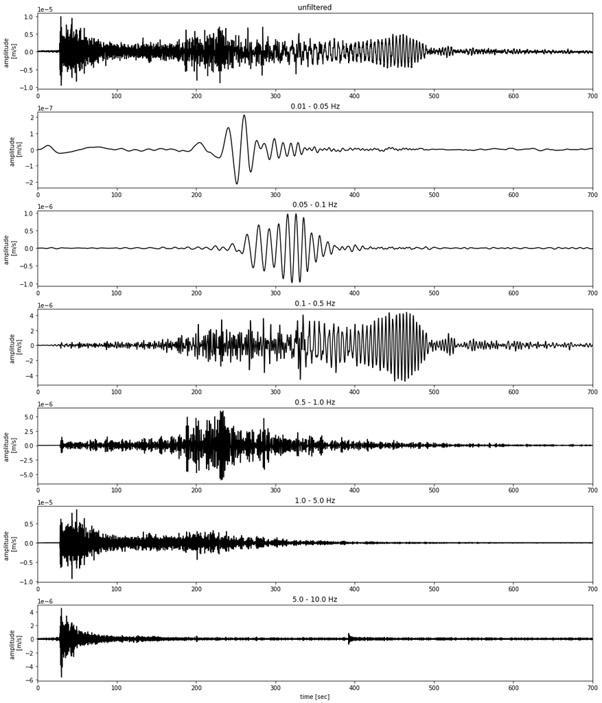

```python
chanel = 2
tm = dat[chanel].times()
xmin = 0
xmax = 700

dat1 = dat[chanel].copy()
dat2 = dat[chanel].copy()
dat2.filter(type="bandpass", freqmin=0.01, freqmax=0.05)
dat3 = dat[chanel].copy()
dat3.filter(type="bandpass", freqmin=0.05, freqmax=0.1)
dat4 = dat[chanel].copy()
dat4.filter(type="bandpass", freqmin=0.1, freqmax=0.5)
dat5 = dat[chanel].copy()
dat5.filter(type="bandpass", freqmin=0.5, freqmax=1)
dat6 = dat[chanel].copy()
dat6.filter(type="bandpass", freqmin=1., freqmax=5.)
dat7 = dat[chanel].copy()
dat7.filter(type="bandpass", freqmin=5., freqmax=10.)

plt.rcParams['figure.figsize'] = 17, 21
fig = plt.figure()
ax1 = fig.add_subplot(7,1,1)
ax1.ticklabel_format(style='sci', axis='y', scilimits=(-1,1))
plt.plot(tm, dat1.data, 'k')
plt.xlim(xmin, xmax)
plt.title('unfiltered')
plt.ylabel('amplitude \n [m/s]')
ax2 = fig.add_subplot(7,1,2)
ax2.ticklabel_format(style='sci', axis='y', scilimits=(-1,1))
plt.plot(tm, dat2.data, 'k')
plt.xlim(xmin, xmax)
plt.title('0.01 - 0.05 Hz')
plt.ylabel('amplitude \n [m/s]')
ax3 = fig.add_subplot(7,1,3)
ax3.ticklabel_format(style='sci', axis='y', scilimits=(-1,1))
plt.plot(tm, dat3.data, 'k')
plt.xlim(xmin, xmax)
plt.title('0.05 - 0.1 Hz')
plt.ylabel('amplitude \n [m/s]')
ax4 = fig.add_subplot(7,1,4)
ax4.ticklabel_format(style='sci', axis='y', scilimits=(-1,1))
plt.plot(tm, dat4.data, 'k')
plt.xlim(xmin, xmax)
plt.title('0.1 - 0.5 Hz')
plt.ylabel('amplitude \n [m/s]')
ax5 = fig.add_subplot(7,1,5)
ax5.ticklabel_format(style='sci', axis='y', scilimits=(-1,1))
plt.plot(tm, dat5.data, 'k')
plt.xlim(xmin, xmax)
plt.title('0.5 - 1.0 Hz')
plt.ylabel('amplitude \n [m/s]')
ax6 = fig.add_subplot(7,1,6)
ax6.ticklabel_format(style='sci', axis='y', scilimits=(-1,1))
plt.plot(tm, dat6.data, 'k')
plt.xlim(xmin, xmax)
plt.title('1.0 - 5.0 Hz')
plt.ylabel('amplitude \n [m/s]')
ax7 = fig.add_subplot(7,1,7)
ax7.ticklabel_format(style='sci', axis='y', scilimits=(-1,1))
plt.plot(tm, dat7.data, 'k')
plt.xlim(xmin, xmax)
plt.title('5.0 - 10.0 Hz')
plt.xlabel('time [sec]')
plt.ylabel('amplitude \n [m/s]')
plt.subplots_adjust(hspace=0.3)
plt.show()
```